# An overview of Bayesian network analysis

Goh Gabriel

04-10-2024

# Introduction to Bayesian Networks

Bayesian Networks, also known as belief networks or probabilistic directed acyclic graphical models, are a powerful framework for representing and reasoning with probabilistic relationships among a set of variables. At its core, a Bayesian Network consists of two main components:

1. A directed acyclic graph (DAG) where nodes represent random variables and edges represent direct dependencies between these variables.
2. A set of conditional probability distributions associated with each node, quantifying the relationship between a node and its parents in the graph.

Formally, we can define a Bayesian Network B as a pair (G, Θ), where:

G = (V, E) is a directed acyclic graph with vertices V representing random variables and edges E representing direct dependencies. Θ = {P(Xi | Pa(Xi)) : Xi ∈ V} is the set of conditional probability distributions for each variable Xi given its parents Pa(Xi) in the graph.

The structure of the DAG encodes conditional independence assumptions, which allow for a compact representation of the joint probability distribution over all variables. This factorization is a key strength of Bayesian Networks, as it enables efficient inference and learning algorithms.

## Historical Context

Bayesian Networks emerged in the 1980s as a synthesis of ideas from artificial intelligence, statistics, and computer science. Key milestones in their development include:

- 1985: Judea Pearl’s seminal work on probabilistic reasoning in intelligent systems, which laid the foundation * for Bayesian Networks.
- 1988: Lauritzen and Spiegelhalter’s development of efficient exact inference algorithms for Bayesian Networks.
- 1990s: Advancements in structure learning algorithms and the application of Bayesian Networks to various domains, including medical diagnosis and gene regulatory networks.
- 2000s onwards: Integration with other machine learning techniques, development of dynamic and object-oriented Bayesian Networks, and applications in big data and causal inference.

## Comparison with other models

Bayesian Networks offer several advantages over traditional statistical methods:

1. Interpretability: The graphical structure provides an intuitive representation of relationships between variables, making it easier for domain experts to understand and validate the model.
2. Flexibility: Bayesian Networks can handle both discrete and continuous variables, missing data, and can incorporate prior knowledge into the model.
3. Bidirectional inference: Unlike many predictive models, Bayesian Networks allow for both predictive (from causes to effects) and diagnostic (from effects to causes) reasoning.
4. Explicit modeling of uncertainty: The probabilistic nature of Bayesian Networks allows for a natural representation of uncertainty in both the model structure and parameters.
5. Causal reasoning: The directed nature of the graph can represent causal relationships, enabling causal inference under certain assumptions.

Compared to other methods:

1. Regression models: While powerful for prediction, traditional regression models often assume a fixed set of predictors and a single outcome. Bayesian Networks can model complex interdependencies among multiple variables simultaneously.
2. Structural Equation Models (SEM): Both SEMs and Bayesian Networks can represent causal relationships, but Bayesian Networks offer more flexibility in handling non-linear relationships and discrete variables.
3. Neural Networks: While neural networks excel at pattern recognition and prediction, they often lack interpretability. Bayesian Networks provide a more transparent model of the domain.
4. Decision Trees: Bayesian Networks can capture more complex probabilistic relationships than decision trees and are more robust to noisy data.

We cover this in more detail in the lateer sections.

# Fundamental Components of Bayesian Networks

In this section, we briefly cover the essential math components of Bayesian network analysis.

## Nodes and Variables

In a Bayesian Network, nodes represent random variables. These variables can be:

- discrete: taking on a finite or countably infinite set of values (e.g., binary outcomes, categorical variables)
- continuous: taking on values in a continuous range (e.g., real numbers)
- or mixed: networks can contain both discrete and continuous variables

Each node corresponds to a random variable X_i, which can represent observable data, latent variables, or parameters of interest.

## Edges and Conditional Dependencies

Edges in a Bayesian Network are directed and represent direct probabilistic dependencies between variables. If there’s an edge from node A to node B, we say:

- A is a parent of B
- B is a child of A
- The edge indicates that A directly influences B

The absence of an edge between two nodes implies conditional independence given the other variables in the network.

Key concepts:

- Markov condition: each variable is conditionally independent of its non-descendants, given its parents
- Local Markov property: any given variable is conditionally independent of all other variables given its Markov blanket (parents, children, and children’s other parents)

## Conditional Probability Tables (CPTs)

For discrete variables, the relationship between a node and its parents is quantified using Conditional Probability Tables (CPTs). A CPT specifies the probability distribution of the variable for each possible combination of its parents’ values.

For a node X with parents Y_1, …, Y_n, the CPT provides P(X | Y_1, …, Y_n).

Example CPT for a binary variable C with binary parents A and B:

```
A | B | P(C=0 | A,B) | P(C=1 | A,B)
-----------------------------------------
0 | 0 |    0.7      |    0.3
0 | 1 |    0.4      |    0.6
1 | 0 |    0.5      |    0.5
1 | 1 |    0.1      |    0.9
```

For continuous variables, conditional probability densities are used instead, often represented as parametric distributions (e.g., Gaussian with mean and variance depending on parent values).

## Joint Probability Distribution

A key feature of Bayesian Networks is their ability to compactly represent the joint probability distribution over all variables. Given a Bayesian Network with variables X_1, …, X_n, the joint distribution can be factored as:

```
P(X_1, ..., X_n) = ∏_{i=1}^n P(X_i | Pa(X_i))
```

Where Pa(X_i) represents the parents of X_i in the network.

This factorization, based on the chain rule of probability and the conditional independence assumptions encoded in the graph, is fundamental to the efficiency of Bayesian Networks in representing and computing with high-dimensional probability distributions.

The structure of the network, combined with the local probability distributions (CPTs), fully specifies the joint distribution over all variables. This allows for various types of probabilistic inference, including:

- Marginal inference: computing the probability of a subset of variables
- Conditional inference: computing the probability of some variables given evidence on others
- Most probable explanation (MPE): finding the most likely assignment to all unobserved variables given evidence

# Graph Theory in Bayesian Networks

In this section, we cover the basic graph theory underlying Bayesian Networks, which provides the foundation for understanding independence relationships and efficient inference algorithms. It presupposes that the reader has some basic knowledge of statistical network analysis, although it is not mandatory for understanding Bayesian Networks.

## Directed Acyclic Graphs (DAGs)

Bayesian Networks are built upon Directed Acyclic Graphs (DAGs). There are two key properties of DAGs: directed (each edge has a direction, pointing from one node to another), and acyclic (there are no directed cycles in the graph)

Important concepts:

- Path: A sequence of edges connecting two nodes.
- Directed path: A path where all edges point in the same direction.
- Ancestor: Node A is an ancestor of B if there’s a directed path from A to B.
- Descendant: Node B is a descendant of A if there’s a directed path from A to B.

The acyclicity constraint in Bayesian Networks is crucial as it allows for a well-defined joint probability factorization, efficient inference algorithms, and causal interpretation under certain assumptions.

## D-separation and Independence

D-separation (directional separation) is a criterion for identifying conditional independence relationships in a DAG. It’s fundamental to understanding the independence properties encoded by the network structure.

Three basic structures in DAGs:

1. Chain: A → B → C
2. Fork: A ← B → C
3. Collider (v-structure): A → B ← C

D-separation rules:

1. In a chain or fork, B blocks the path between A and C unless B is observed.
2. In a collider, B opens the path between A and C if B or any of its descendants are observed.

Two nodes are d-separated given a set of nodes Z if all paths between them are blocked according to these rules. D-separation implies conditional independence in the probability distribution represented by the Bayesian Network.

## Markov Blanket

The Markov blanket of a node X is the minimal set of nodes that, when observed, render X conditionally independent of all other nodes in the network. It consists of:

1. X’s parents
2. X’s children
3. The other parents of X’s children

The Markov blanket shields the node from the rest of the network in terms of probabilistic influence, and in this sense, is the minimal set of nodes needed to predict the behavior of X. Markov blankets play a crucial role in local inference and learning algorithms.

For example, consider a simple Bayesian Network:

```
  A → B → C
  ↓   ↗
  D
```

The Markov blanket of B would be {A, C, D}.

Understanding these graph-theoretic concepts is crucial for interpreting the independence assumptions encoded in a Bayesian Network. Further, it helps in designing efficient inference algorithms, learning network structure from data, and allows for the reasoning about potential causal relationships.

# Probability Theory and Bayesian Inference

In this section, we’ll delve into probability theory and Bayesian inference, building upon these graphical concepts to perform quantitative reasoning in Bayesian Networks. Having some knowledge about Bayesian statistics (https://www.youtube.com/watch?v=3jP4H0kjtng) is helpful going into this section.

## Bayes Theorem

Bayes’ theorem is the foundational principle underlying Bayesian inference. It provides a way to update probabilities based on new evidence:

P(A|B) = P(B|A) * P(A) / P(B)

Where:

- P(A|B) is the posterior probability of A given B
- P(B|A) is the likelihood of B given A
- P(A) is the prior probability of A
- P(B) is the marginal likelihood or evidence

In Bayesian Networks, this theorem is applied repeatedly to perform various types of probabilistic inference.

## Chain Rule and Factorization

The chain rule of probability allows us to express the joint probability of multiple variables as a product of conditional probabilities:

P(X₁, X₂, …, Xn) = P(X₁) * P(X₂|X₁) * P(X₃|X₁,X₂) * … * P(Xn|X₁,…,Xn-1)

In Bayesian Networks, we exploit the conditional independence assumptions encoded in the graph structure to simplify this factorization:

P(X₁, X₂, …, Xn) = ∏ P(Xi | Parents(Xi))

This factorization is key to the compact representation of joint probabilities in Bayesian Networks.

## Inference Algorithms

Inference in Bayesian Networks involves computing probabilities of interest given evidence. Two main types of inference algorithms are:

### a) Exact Inference:

Variable Elimination:

- Progressively marginalizes out variables not of interest
- Order of elimination affects efficiency
- Complexity depends on the network’s structure and the query

Junction Tree Algorithm:

- Converts the network into a tree of cliques
- Performs message passing between cliques
- Allows for efficient multiple queries once the junction tree is constructed

### b) Approximate Inference:

Monte Carlo methods:

- Gibbs sampling
- Likelihood weighting

Variational methods:

- Mean field approximation
- Belief propagation

In the below section, I will provide an example of variable elimination:

```
Variable Elimination Algorithm:

1. Choose an elimination ordering for variables not in the query or evidence
2. For each variable in the elimination ordering: Multiply all factors containing the variable, then sum out the variable from the resulting factor
3. Multiply remaining factors and normalize

Example:

    Consider a simple network: A → B → C

    Query: P(C|A=a)

    Steps:

    1. Factors: P(A), P(B|A), P(C|B)
    2. Eliminate B: Multiply P(B|A) and P(C|B), then sum out B: ∑B P(B|A=a) * P(C|B)
    3. Multiply with P(A=a) and normalize
```

The choice of inference algorithm depends on the network structure, the types of queries, and computational constraints. Exact inference becomes intractable for large, densely connected networks, necessitating approximate methods. Understanding these inference techniques is crucial for effectively using Bayesian Networks in practice, as they allow us to answer probabilistic queries and make predictions based on the model.

## Learning Bayesian Networks

In this section, we’ll explore methods for learning Bayesian Networks from data, including both structure learning and parameter estimation.

## Structure Learning

Structure learning aims to determine the graph structure (i.e. edges between nodes) that best represents the dependencies in the data. There are usually three approaches:

### Constraint-based Methods

These methods use statistical tests to identify conditional independence relationships in the data, then construct a graph that satisfies these relationships.

```
Key algorithm: PC Algorithm (named after its inventors, Peter Spirtes and Clark Glymour)
  Steps:

  1. Start with a fully connected undirected graph
  2. For each pair of variables, test for conditional independence given subsets of other variables
  3. Remove edges between conditionally independent variables
  4. Orient edges based on identified v-structures and other rules

Pros: Can handle high-dimensional data
Cons: Sensitive to errors in independence tests
```

### Score-based Methods

These methods define a scoring function to measure how well a graph structure fits the data, then search for the structure with the best score. Some of the common ones may be familiar, e.g. Bayesian Information Criterion (BIC), Bayesian Dirichlet equivalent uniform (BDeu) score.

There are also some search strategies, including greedy search, simulated annealing, and genetic algorithms.

```
Example (Greedy search):

  1. Start with an empty (or random) graph
  2. Iteratively add, remove, or reverse edges to improve the score
  3. Stop when no improvement is possible

Pros: Can incorporate prior knowledge easily
Cons: Can be computationally expensive for large networks
```

### Hybrid Methods

These methods combine elements of constraint-based and score-based approaches to leverage the strengths of both.

```
Example: Max-Min Hill-Climbing (MMHC) algorithm

  Use constraint-based methods to learn the skeleton (undirected graph)
  Use score-based methods to orient the edges
```

## Parameter Learning

Once the structure is determined, we need to learn the parameters of the conditional probability distributions for each node.

### Maximum Likelihood Estimation (MLE)

For discrete variables, MLE estimates the conditional probabilities as the empirical frequencies in the data:

P(Xi = xi | Pa(Xi) = pa_i) = N(Xi = xi, Pa(Xi) = pa_i) / N(Pa(Xi) = pa_i)

Where N() represents the count in the data.

For continuous variables with parametric distributions (e.g., Gaussian), MLE estimates the parameters that maximize the likelihood of the data.

### Bayesian Estimation

Bayesian estimation incorporates prior knowledge about the parameters and computes a posterior distribution over the parameters given the data.

For discrete variables, a common approach is to use Dirichlet priors, leading to the posterior:

P(Xi = xi | Pa(Xi) = pa_i, Data) ∝ Dir(α + N)

Where α represents the prior counts and N the observed counts.

The main advantages of Bayesian estimation are that it handles small sample sizes better, allows for us to incorporate informative prior knowledge, and also provides uncertainty estimates for parameters.

### Summary

Learning algorithms often need to handle missing data (using methods like Expectation-Maximization [EM]), hidden variables (by employing techniques similar to those used for missing data), as well as continuous variables (which require the use of discretization or parametric distributions). For these reasons, main challenges in learning Bayesian Networks are in their computational complexity, the requirement for large amounts of data, and in the inability to produce causal relationships without additional assumptions.

In practice, it’s often beneficial to combine domain knowledge with data-driven learning, using expert input to constrain the space of possible structures or set priors for Bayesian learning approaches.

# Advanced Topics in Bayesian Networks

With the basics out of the way, now we can explore some advanced topics in Bayesian networks, including dynamic and object-oriented extensions.

## Dynamic Bayesian Networks (DBNs)

Dynamic Bayesian Networks extend the standard Bayesian Network framework to model temporal processes.

- Represent variables that change over time
- Consist of repeating “time slices,” each containing a set of variables
- Edges can connect variables within a time slice or between adjacent time slices

```
Structure:

Initial network (for t=0)
Transition network (for t>0)
Assumption: First-order Markov property (future states depend only on the current state)

Applications:

Speech recognition
Gene regulatory network modeling
Financial time series analysis

Inference in DBNs:

Filtering: P(X_t | Y_1:t)
Smoothing: P(X_t | Y_1:T), where T > t
Prediction: P(X_t+k | Y_1:t)

Algorithms:

Forward-backward algorithm
Particle filtering for approximate inference
```

## Object-oriented Bayesian Networks (OOBNs)

OOBNs provide a framework for modeling complex systems with repeating substructures.

Key concepts:

1. Classes: Define reusable network fragments
2. Instances: Specific realizations of a class
3. Reference nodes: Allow connections between instances

The advantages of OOBNs are in their modular design, reusability of model components, and are scalable to large, complex domains.

Example application: modeling a manufacturing process with multiple similar machines, each represented by an instance of a “Machine” class.

## Influence Diagrams and Decison Networks

Influence Diagrams extend Bayesian Networks to support decision-making under uncertainty by providing additional node types: decision nodes, which represent choices available to the decision-maker, and utility nodes, which represent the desirability of outcomes.

Structure:

- Chance nodes (as in standard Bayesian Networks)
- Decision nodes (typically rectangular)
- Utility nodes (typically diamond-shaped)
- Edges represent both probabilistic and functional dependencies

Key concepts:

- Maximum Expected Utility (MEU): Optimal decision strategy
- Value of Information (VoI): Worth of obtaining additional information before making a decision

An example of a simple influence diagram solving might involve a simple conversion to a decision tree, and then applying some dynamic programming like backward induction. There are some specialized algorithms for efficient solutions in large networks, which are mainly used in domains such as medical decision support, business strategy planning, as well as environmental policy making.

```
Example:
An influence diagram for deciding whether to bring an umbrella, with nodes for:

Weather forecast (chance node)
Actual weather (chance node)
Bring umbrella decision (decision node)
Comfort level (utility node)
```

# Applications of Bayesian Networks

Bayesian Networks have found applications in numerous fields due to their flexibility and interpretability.

## Classification and Prediction

Bayesian Networks can be used for both classification and prediction tasks.

Classification:

- Naive Bayes classifier: A simple Bayesian Network where all features are assumed to be conditionally independent given the class
- Tree Augmented Naive Bayes (TAN): Relaxes the independence assumption by allowing a tree structure among features
- General Bayesian Network classifiers: Use more complex structures to capture feature dependencies

```
Example: Medical diagnosis

Nodes: Symptoms, risk factors, diseases
Predict the most likely disease given observed symptoms and patient characteristics
```

Prediction:

Use the network to infer the probability distribution of target variables given evidence

```
Example: Weather forecasting

Nodes: Temperature, humidity, air pressure, cloud cover
Predict probability of rain given observed meteorological data
```

```r
# First, install BiocManager if you haven't already
if (!requireNamespace("BiocManager", quietly = TRUE))
    install.packages("BiocManager")

# Then, use BiocManager to install Rgraphviz
BiocManager::install("Rgraphviz")
if (!requireNamespace("bnlearn", quietly = TRUE))
    install.packages("bnlearn")

# After installation, you can load the package
library(Rgraphviz)
library(bnlearn)
# Load required libraries
library(bnlearn)
library(Rgraphviz)  # For advanced plotting

# Set seed for reproducibility
set.seed(123)

# Create simulated data
n_samples <- 1000
weather_data <- data.frame(
  Temperature = factor(sample(c("Low", "Medium", "High"), n_samples, replace = TRUE, prob = c(0.3, 0.4, 0.3))),
  Humidity = factor(sample(c("Low", "Medium", "High"), n_samples, replace = TRUE, prob = c(0.3, 0.4, 0.3))),
  AirPressure = factor(sample(c("Low", "Medium", "High"), n_samples, replace = TRUE, prob = c(0.3, 0.4, 0.3))),
  CloudCover = factor(sample(c("Clear", "Partly Cloudy", "Overcast"), n_samples, replace = TRUE, prob = c(0.3, 0.4, 0.3)))
)

# Add Rain variable with dependencies on other variables
weather_data$Rain <- factor(sapply(1:n_samples, function(i) {
  prob_heavy <- 0.1 +
    (weather_data$Temperature[i] == "High") * 0.2 +
    (weather_data$Humidity[i] == "High") * 0.3 +
    (weather_data$AirPressure[i] == "Low") * 0.2 +
    (weather_data$CloudCover[i] == "Overcast") * 0.2

  # Ensure prob_heavy is between 0 and 1
  prob_heavy <- max(0, min(1, prob_heavy))

  # Adjust other probabilities to ensure they sum to 1
  prob_light <- max(0, 0.7 - prob_heavy/2)
  prob_moderate <- max(0, 1 - prob_heavy - prob_light)

  # Normalize probabilities
  total_prob <- prob_light + prob_moderate + prob_heavy
  prob_light <- prob_light / total_prob
  prob_moderate <- prob_moderate / total_prob
  prob_heavy <- prob_heavy / total_prob

  sample(c("Light", "Moderate", "Heavy"), 1, prob = c(prob_light, prob_moderate, prob_heavy))
}))

# Define the network structure
weather_net <- model2network("[Temperature][Humidity][AirPressure][CloudCover][Rain|Temperature:Humidity:AirPressure:CloudCover]")

# Fit the network parameters
weather_net_fitted <- bn.fit(weather_net, weather_data, method = "bayes")

# Perform inference
evidence <- list(
  Temperature = factor("High", levels = levels(weather_data$Temperature)),
  Humidity = factor("High", levels = levels(weather_data$Humidity)),
  AirPressure = factor("Low", levels = levels(weather_data$AirPressure)),
  CloudCover = factor("Overcast", levels = levels(weather_data$CloudCover))
)

query <- cpquery(
  weather_net_fitted,
  event = (Rain == "Heavy"),
  evidence = (Temperature == "High" &
              Humidity == "High" &
              AirPressure == "Low" &
              CloudCover == "Overcast")
)

print(paste("Probability of heavy rain given the evidence:", round(query, 3)))
```

```
## [1] "Probability of heavy rain given the evidence: 0.621"
```

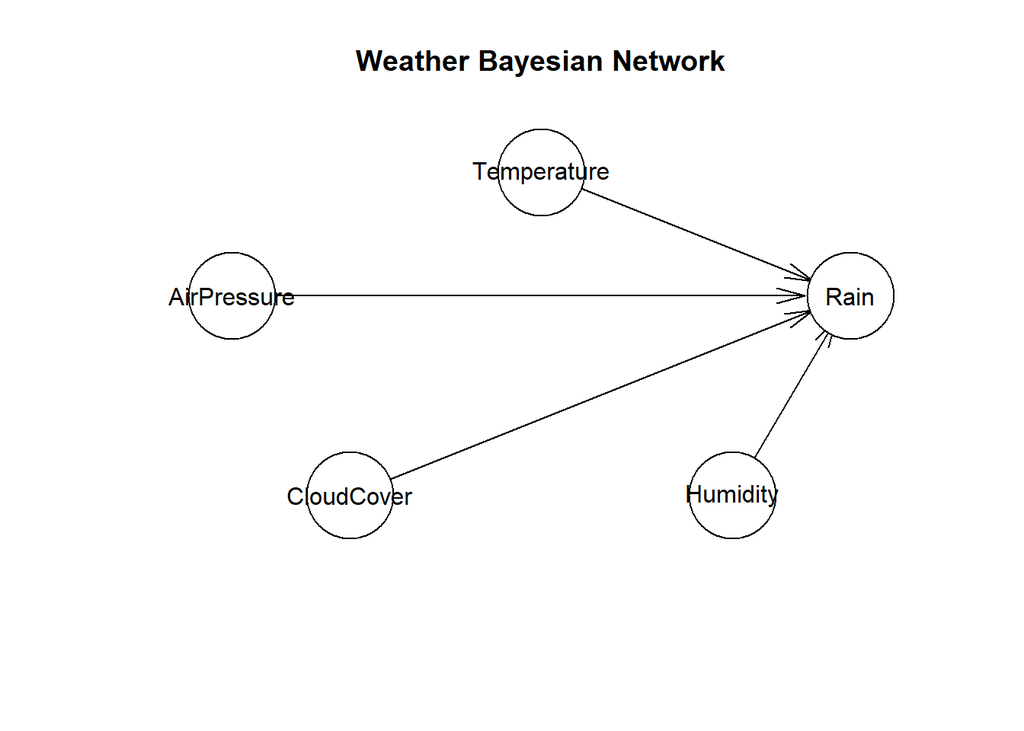

```r
# Visualize the network
plot(weather_net, main = "Weather Bayesian Network")
```

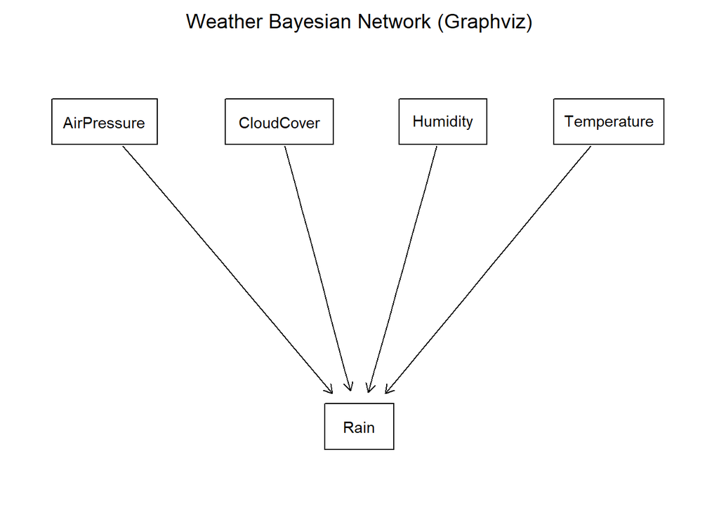

```r
# For a more advanced plot (requires Rgraphviz)
graphviz.plot(weather_net, main = "Weather Bayesian Network (Graphviz)")
```

```r
# Load required libraries
library(bnlearn)
library(Rgraphviz)

# Set seed for reproducibility
set.seed(123)

# Create simulated data (same as before)
n_samples <- 1000
weather_data <- data.frame(
  Temperature = factor(sample(c("Low", "Medium", "High"), n_samples, replace = TRUE, prob = c(0.3, 0.4, 0.3))),
  Humidity = factor(sample(c("Low", "Medium", "High"), n_samples, replace = TRUE, prob = c(0.3, 0.4, 0.3))),
  AirPressure = factor(sample(c("Low", "Medium", "High"), n_samples, replace = TRUE, prob = c(0.3, 0.4, 0.3))),
  CloudCover = factor(sample(c("Clear", "Partly Cloudy", "Overcast"), n_samples, replace = TRUE, prob = c(0.3, 0.4, 0.3)))
)

# Add Rain variable (same as before)
weather_data$Rain <- factor(sapply(1:n_samples, function(i) {
  prob_heavy <- 0.1 +
    (weather_data$Temperature[i] == "High") * 0.2 +
    (weather_data$Humidity[i] == "High") * 0.3 +
    (weather_data$AirPressure[i] == "Low") * 0.2 +
    (weather_data$CloudCover[i] == "Overcast") * 0.2

  prob_heavy <- max(0, min(1, prob_heavy))
  prob_light <- max(0, 0.7 - prob_heavy/2)
  prob_moderate <- max(0, 1 - prob_heavy - prob_light)

  total_prob <- prob_light + prob_moderate + prob_heavy
  prob_light <- prob_light / total_prob
  prob_moderate <- prob_moderate / total_prob
  prob_heavy <- prob_heavy / total_prob

  sample(c("Light", "Moderate", "Heavy"), 1, prob = c(prob_light, prob_moderate, prob_heavy))
}))

# Define the graphical prior
graphical_prior <- empty.graph(nodes = c("Temperature", "Humidity", "AirPressure", "CloudCover", "Rain"))

# Add edges based on expert knowledge
graphical_prior <- set.arc(graphical_prior, from = "Temperature", to = "Humidity")
graphical_prior <- set.arc(graphical_prior, from = "AirPressure", to = "CloudCover")
graphical_prior <- set.arc(graphical_prior, from = "Temperature", to = "Rain")
graphical_prior <- set.arc(graphical_prior, from = "Humidity", to = "Rain")
graphical_prior <- set.arc(graphical_prior, from = "AirPressure", to = "Rain")
graphical_prior <- set.arc(graphical_prior, from = "CloudCover", to = "Rain")

# Create whitelist and blacklist
whitelist <- arcs(graphical_prior)
all_nodes <- nodes(graphical_prior)
all_possible_arcs <- expand.grid(from = all_nodes, to = all_nodes)
all_possible_arcs <- all_possible_arcs[all_possible_arcs$from != all_possible_arcs$to, ]
blacklist <- all_possible_arcs[!paste(all_possible_arcs$from, all_possible_arcs$to) %in% paste(whitelist[,1], whitelist[,2]), ]

# Learn the network structure using the graphical prior
weather_net_learned <- hc(weather_data, score = "bic", restart = 10, perturb = 10,
                          blacklist = blacklist, whitelist = whitelist)

# Define the evidence
evidence <- list(
  Temperature = "High",
  Humidity = "High",
  AirPressure = "Low",
  CloudCover = "Overcast"
)

# Function to check if a set of variables d-separates two other variables
is_d_separated <- function(x, y, z, graph) {
  dsep(graph, x, y, z)
}

# Identify the Markov blanket of Rain in the learned structure
rain_mb <- mb(weather_net_learned, "Rain")

rain_mb
```

```
## [1] "Temperature" "Humidity"    "AirPressure" "CloudCover"
```

```r
# Calculate the probability of heavy rain given the evidence
relevant_vars <- c("Rain", rain_mb)
relevant_data <- weather_data[, relevant_vars]
relevant_evidence <- evidence[names(evidence) %in% rain_mb]

matching_rows <- apply(relevant_data[, names(relevant_evidence), drop = FALSE], 1,
                       function(row) all(row == unlist(relevant_evidence)))

prob_heavy_rain <- sum(relevant_data$Rain[matching_rows] == "Heavy") / sum(matching_rows)

print(paste("Probability of heavy rain given the evidence (based on learned structure):", round(prob_heavy_rain, 3)))
```

```
## [1] "Probability of heavy rain given the evidence (based on learned structure): 0.667"
```

```r
# Check d-separation between Rain and each evidence variable
for (var in names(evidence)) {
  if (var != "Rain") {
    other_vars <- setdiff(names(evidence), c("Rain", var))
    d_sep <- is_d_separated("Rain", var, other_vars, weather_net_learned)
    print(paste("Rain and", var, "are d-separated given other variables:", d_sep))
  }
}
```

```
## [1] "Rain and Temperature are d-separated given other variables: FALSE"
## [1] "Rain and Humidity are d-separated given other variables: FALSE"
## [1] "Rain and AirPressure are d-separated given other variables: FALSE"
## [1] "Rain and CloudCover are d-separated given other variables: FALSE"
```

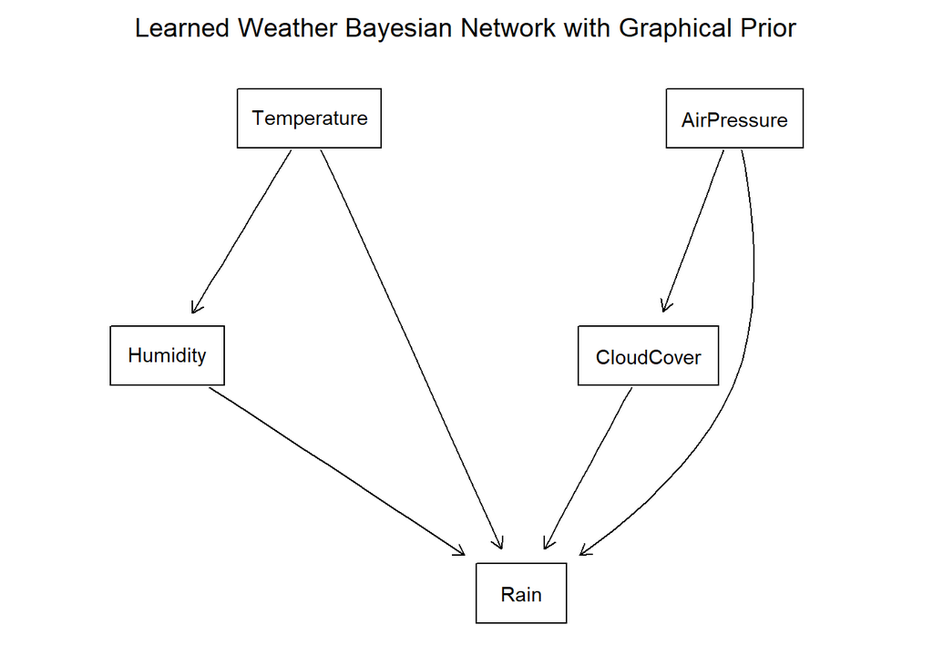

```r
# Visualize the learned network
graphviz.plot(weather_net_learned, main = "Learned Weather Bayesian Network with Graphical Prior")
```

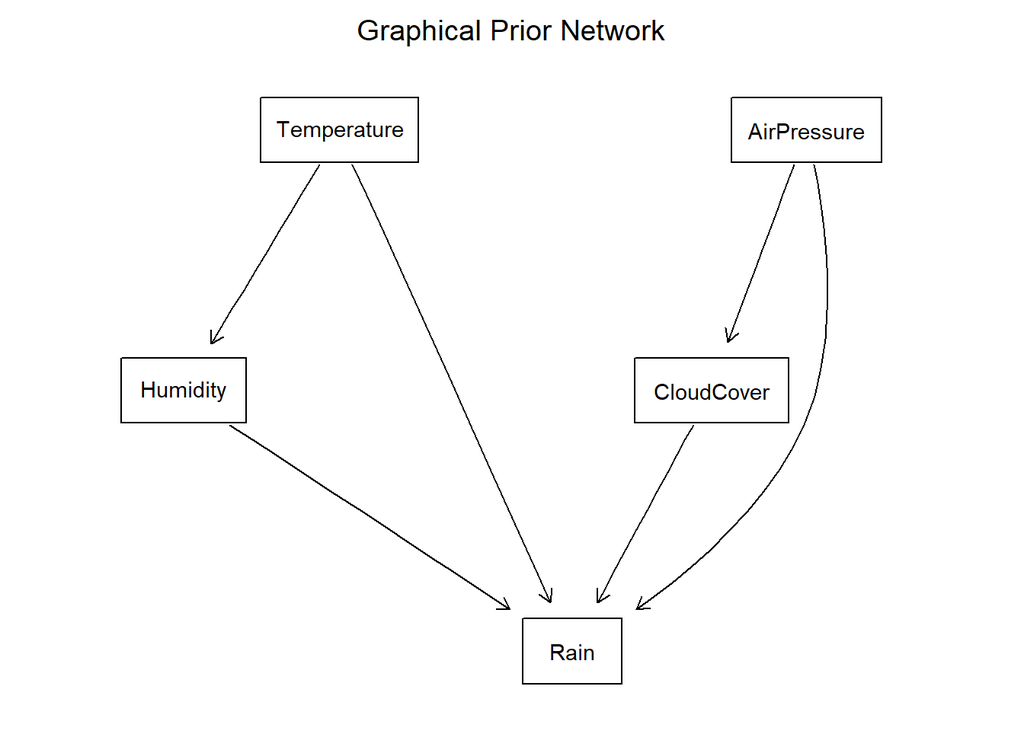

```r
# Compare with the prior network
graphviz.plot(graphical_prior, main = "Graphical Prior Network")
```

```r
# Define the graphical prior
graphical_prior <- empty.graph(nodes = c("Temperature", "Humidity", "AirPressure", "CloudCover", "Rain"))
graphical_prior <- set.arc(graphical_prior, from = "Temperature", to = "Humidity")
graphical_prior <- set.arc(graphical_prior, from = "AirPressure", to = "CloudCover")
graphical_prior <- set.arc(graphical_prior, from = "Temperature", to = "Rain")
graphical_prior <- set.arc(graphical_prior, from = "Humidity", to = "Rain")
graphical_prior <- set.arc(graphical_prior, from = "AirPressure", to = "Rain")
graphical_prior <- set.arc(graphical_prior, from = "CloudCover", to = "Rain")

# Create whitelist and blacklist for the graphical prior
whitelist <- arcs(graphical_prior)
all_nodes <- nodes(graphical_prior)
all_possible_arcs <- expand.grid(from = all_nodes, to = all_nodes)
all_possible_arcs <- all_possible_arcs[all_possible_arcs$from != all_possible_arcs$to, ]
blacklist <- all_possible_arcs[!paste(all_possible_arcs$from, all_possible_arcs$to) %in% paste(whitelist[,1], whitelist[,2]), ]

# Learn the network structure using the graphical prior
weather_net_graphical <- hc(weather_data, score = "bic", restart = 10, perturb = 10,
                            blacklist = blacklist, whitelist = whitelist)

# Learn the network structure with a flat prior (no constraints)
weather_net_flat <- hc(weather_data, score = "bic", restart = 10, perturb = 10)

# Function to check d-separation
is_d_separated <- function(x, y, z, graph) {
  dsep(graph, x, y, z)
}

# Function to print d-separation results
print_d_separation <- function(net, name) {
  cat("\nD-separation results for", name, ":\n")
  for (var in c("Temperature", "Humidity", "AirPressure", "CloudCover")) {
    other_vars <- setdiff(c("Temperature", "Humidity", "AirPressure", "CloudCover"), var)
    d_sep <- is_d_separated("Rain", var, other_vars, net)
    cat("Rain and", var, "are d-separated given other variables:", d_sep, "\n")
  }
}

# Print d-separation results for both networks
print_d_separation(weather_net_graphical, "Graphical Prior Network")
```

```
##
## D-separation results for Graphical Prior Network :
## Rain and Temperature are d-separated given other variables: FALSE
## Rain and Humidity are d-separated given other variables: FALSE
## Rain and AirPressure are d-separated given other variables: FALSE
## Rain and CloudCover are d-separated given other variables: FALSE
```

```r
print_d_separation(weather_net_flat, "Flat Prior Network")
```

```
##
## D-separation results for Flat Prior Network :
## Rain and Temperature are d-separated given other variables: FALSE
## Rain and Humidity are d-separated given other variables: FALSE
## Rain and AirPressure are d-separated given other variables: FALSE
## Rain and CloudCover are d-separated given other variables: TRUE
```

```r
# Compare network structures
cat("\nNetwork structure comparison:\n")
```

```
##
## Network structure comparison:
```

```r
cat("Graphical Prior Network:\n")
```

```
## Graphical Prior Network:
```

```r
print(weather_net_graphical)
```

```
##
##   Bayesian network learned via Score-based methods
##
##   model:
##    [Temperature][AirPressure][Humidity|Temperature][CloudCover|AirPressure]
##    [Rain|Temperature:Humidity:AirPressure:CloudCover]
##   nodes:                                 5
##   arcs:                                  6
##     undirected arcs:                     0
##     directed arcs:                       6
##   average markov blanket size:           4.00
##   average neighbourhood size:            2.40
##   average branching factor:              1.20
##
##   learning algorithm:                    Hill-Climbing
##   score:                                 BIC (disc.)
##   penalization coefficient:              3.453878
##   tests used in the learning procedure:  6
##   optimized:                             TRUE
```

```r
cat("\nFlat Prior Network:\n")
```

```
##
## Flat Prior Network:
```

```r
print(weather_net_flat)
```

```
##
##   Bayesian network learned via Score-based methods
##
##   model:
##    [Humidity][CloudCover][Rain|Humidity][Temperature|Rain][AirPressure|Rain]
##   nodes:                                 5
##   arcs:                                  3
##     undirected arcs:                     0
##     directed arcs:                       3
##   average markov blanket size:           1.20
##   average neighbourhood size:            1.20
##   average branching factor:              0.60
##
##   learning algorithm:                    Hill-Climbing
##   score:                                 BIC (disc.)
##   penalization coefficient:              3.453878
##   tests used in the learning procedure:  277
##   optimized:                             TRUE
```

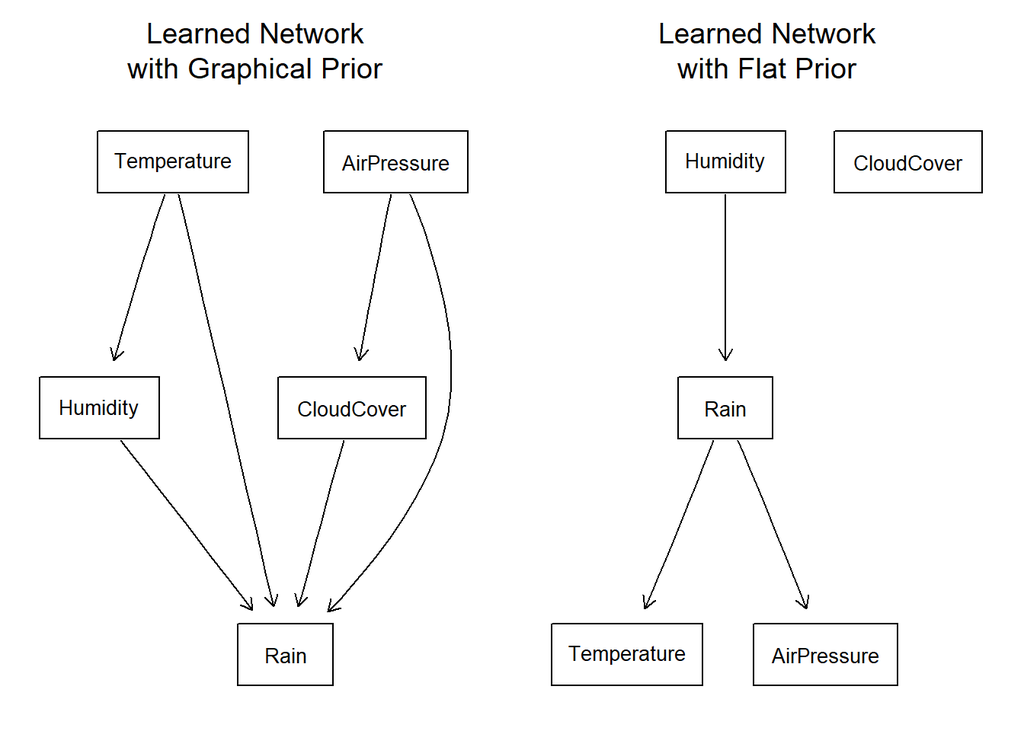

```r
# Visualize both networks
par(mfrow = c(1, 2))
graphviz.plot(weather_net_graphical, main = "Learned Network\nwith Graphical Prior")
graphviz.plot(weather_net_flat, main = "Learned Network\nwith Flat Prior")
```

```r
# Reset plot layout
par(mfrow = c(1, 1))

# Compare network scores
score_graphical <- score(weather_net_graphical, data = weather_data, type = "bic")
score_flat <- score(weather_net_flat, data = weather_data, type = "bic")

cat("\nNetwork scores (BIC, higher is better):\n")
```

```
##
## Network scores (BIC, higher is better):
```

```r
cat("Graphical Prior Network:", score_graphical, "\n")
```

```
## Graphical Prior Network: -5709.949
```

```r
cat("Flat Prior Network:", score_flat, "\n")
```

```
## Flat Prior Network: -5280.249
```

```r
weather_data
```

| Temperature | Humidity | AirPressure | CloudCover | Rain |
| --- | --- | --- | --- | --- |
| Medium | Medium | Medium | Partly Cloudy | Light |
| Low | High | Medium | Clear | Heavy |
| High | Medium | Medium | Partly Cloudy | Heavy |
| Low | Low | High | Overcast | Heavy |
| Low | Low | High | Partly Cloudy | Light |
| Medium | High | High | Overcast | Heavy |
| High | Low | High | Clear | Moderate |
| Low | Medium | Medium | Overcast | Light |
| High | Medium | Medium | Clear | Heavy |
| High | High | Medium | Clear | Light |

[output cut: 990 more lines]

```r
# Fit parameters to both network structures
weather_net_graphical_fitted <- bn.fit(weather_net_graphical, data = weather_data)
weather_net_flat_fitted <- bn.fit(weather_net_flat, data = weather_data)

query1 <- cpquery(
  weather_net_graphical_fitted,
  event = (Rain == "Heavy"),
  evidence = (Temperature == "High" &
              Humidity == "High" &
              AirPressure == "Low" &
              CloudCover == "Overcast")
)

print(paste("Probability of heavy rain given the evidence:", round(query1, 3)))
```

```
## [1] "Probability of heavy rain given the evidence: 0.623"
```

```r
query2 <- cpquery(
  weather_net_graphical_fitted,
  event = (Rain == "Heavy"),
  evidence = (Temperature == "High" &
              Humidity == "High" &
              AirPressure == "Low" &
              CloudCover == "Overcast")
)

print(paste("Probability of heavy rain given the evidence:", round(query2, 3)))
```

```
## [1] "Probability of heavy rain given the evidence: 0.675"
```

## Causal Inference

Bayesian Networks can be used for causal reasoning under certain assumptions (e.g., causal sufficiency, no unmeasured confounders).

Key concepts:

- Do-calculus: Framework for reasoning about interventions
- Counterfactual reasoning: Evaluating “what-if” scenarios

Applications:

- Epidemiology: Identifying causal factors in disease spread
- Economics: Analyzing policy interventions
- Social sciences: Studying causal relationships in social phenomena

```
Example: Evaluating a marketing campaign

Nodes: Campaign exposure, customer characteristics, purchase behavior
Infer causal effect of the campaign on sales
```

## Anomaly Detection

Bayesian Networks can identify unusual patterns or events in data, usually using one of two approaches:

- Likelihood-based: Flag instances with low probability under the model
- Conditional probability-based: Identify unlikely combinations of variable values

The main applications can be in areas that aim to detect anomalies quickly and efficiently, such as fraud detection in financial transactions, network intrusion detection, and also quality control in manufacturing.

```
Example: Credit card fraud detection

Nodes: Transaction amount, location, time, merchant type, customer history
Flag transactions with unusually low probability given the customer's typical behavior
```

## Risk Analysis and Decision Support

Bayesian Networks are well-suited for modeling complex systems with uncertainties.

- Explicit representation of uncertainties
- Ability to update beliefs based on new evidence
- Integration with decision theory (using influence diagrams)

Applications:

- Environmental risk assessment
- Project management risk analysis
- Financial portfolio risk evaluation

```
Example: Oil drilling decision support

Nodes: Geological factors, drilling costs, oil prices, environmental risks
Help decide whether and where to drill based on expected utility
```

In general, there are several practical considerations that we need to know when attempting to apply Bayesian network analysis.

- Data quality and quantity: do we have sufficient high-quality data for learning or expert knowledge for structure specification?
- Model complexity: can we strike a good balance between model expressiveness and computational tractability?
- Interpretability: how can we communicate the complicated nature of Bayesian networks to communicate insights to others?
- Handling continuous variables: what is the best way to handle continuous variables? Do we use discretization or appropriate parametric distributions?
- MOdel selection: what kind of Bayesian networks are the best choice? e.g. using Dynamic Bayesian Networks for time-evolving systems when necessary?
- Integration with other methods: can our Bayesian network analysis supplement our other data analysis formats? Should we use Bayesian analysis at all?

While Bayesian Networks provide a powerful framework for reasoning under uncertainty across a wide range of domains, handling these practical considerations is key in maximising the utility of Bayesian network analysis. Their ability to combine domain knowledge with data-driven learning makes them particularly valuable in fields where expert insight is crucial but data may be limited or noisy.

# Computational Considerations and Software Tools

Throughout this notebook, we have mainly used R to illustrate some examples of using Bayesian network analysis. Here, we move on to discuss computational considerations and software tools for working with Bayesian network analysis.

## Complexity and Scalability Issues

Bayesian network analysis, while powerful, can face computational challenges, especially as the network size and complexity increase.

Some key considerations include:

1. Network structure: densely connected networks are more computationally intensive
2. Variable cardinality: higher number of states for discrete variables increases complexity
3. Network size: larger networks generally require more computational resources
4. Type of inference: exact inference is often intractable for large networks

With this in mind, some complexities that stem from these considerations are:

1. Structure learning: generally NP-hard
2. Exact inference: NP-hard in the worst case
3. Parameter learning: generally polynomial time, but can be affected by missing data

These factors usually negatively affect scalability. To handle them, there are several strategies:

1. Approximate inference methods (e.g., variational inference, MCMC): instead of having to brute-force difficult operations (e.g. normalization), approximate inference methods like MCMC get around the problem one way or another (e.g. using asymptotics like in frequentist analysis). The main cost to consider is that there can be some subjectivity as to whether these methods are performing as intended.
2. Parallelization and distributed computing: if some code runs too slow, we can throw more processing power at it. Certainly sometimes using native rather than languages with interpreters can be faster, but as an example, if I were to write this tutorial in C++ instead of R or Python, I would still be writing code. So everyone’s mileage will vary here.
3. Hierarchical or modular network structures: the approach here is to help manage complexity by breaking down large networks into smaller, more manageable components. Earlier, we have discussed OOBNs (encapsulate repeating structures as reusable objects) and DBNs (model temporal processes by replicating network structure over time), which are examples of more computationally manageable ways to perform Bayesian network analysis. In general there is a risk of increasing *model* complexity (e.g. using DBNs) as we try to scale down *computational* complexity, and these trade-offs should be navigated carefully.
4. Optimizing data structures and algorithms: for the more technically inclined, this approach is about tailoring your implementation of the network to the specific problem at hand. At a higher level, this approach can include:
- Sparse matrix representations: for networks with many conditional independencies
- Caching intermediate results: to avoid redundant computations
- Pruning irrelevant variables: focusing only on the Markov blanket of query variables
- Using more efficient data structures: e.g., factor trees instead of tables for CPDs
- Leveraging domain-specific heuristics: to guide search or sampling processes

How effective these optimizations are depends on the skill of the data scientist / quantitative analyst, and thus can vary widely depending on the specific network and inference tasks. As earlier, there’s often a trade-off between development time and runtime efficiency - there’s no point spending 100 hours to optimize an algorithm to run in 1 hour if you only ever need to run it once.

## Popular Software Packages for Bayesian Network Analysis

Several software tools are available for working with Bayesian Networks, ranging from research-oriented libraries to commercial software suites.

### For the enthusiast

In Python:

- PyMC3: Probabilistic programming library with Bayesian Network capabilities
- pgmpy: Library for working with probabilistic graphical models
- pomegranate: Probabilistic modeling library with support for Bayesian Networks

In R:

- bnlearn: Comprehensive package for learning Bayesian Network structure and parameters
- gRain: Package for probability propagation in Bayesian Networks

In Java:

- WEKA: Includes Bayesian Network learning and inference capabilities
- Tetrad: Causal discovery and Bayesian Network modeling tool

```
from pgmpy.models import BayesianNetwork
from pgmpy.estimators import MaximumLikelihoodEstimator
from pgmpy.inference import VariableElimination

# we first define the structure
model = BayesianNetwork([('A', 'B'), ('B', 'C'), ('C', 'D')])

# set the learning parameters
model.fit(data, estimator=MaximumLikelihoodEstimator)

# perform inference
inference = VariableElimination(model)
result = inference.query(['D'], evidence={'A': 1, 'B': 0})
```

### For the commercial level

Commercial software:

- BayesiaLab: Comprehensive Bayesian Network software for modeling and analysis
- Hugin: Graphical user interface and API for Bayesian Network modeling
- Netica: User-friendly software for working with Bayesian Networks and influence diagrams

Which you would want to use depends widely on your use-cases:

- Do you want a graphical user interface vs. programming interface?
- What support for continuous variables do you need?
- Features: do you need structure learning algorithms, parameter learning methods, inference algorithms (exact and approximate), visualization capabilities, etc?
- Do you need it to be integrable with other data analysis tools?

Further, do you need your analysis to be scalable to large networks? Here are several more considerations:

- use of big data technologies (e.g., Apache Spark) for distributed learning and inference
- cloud-based solutions for scalable computation
- GPU acceleration for certain algorithms
- custom implementations of algorithms optimized for specific problem structures

All in all, when working with Bayesian Networks, we need to consider the trade-offs between model complexity, computational resources, and the specific requirements of your application. Choosing the right tools and computational strategies can significantly impact the feasibility and efficiency of Bayesian Network analysis in practice.

# Bayesian network analysis versus other methods

In this section, we’ll compare Bayesian Networks with related methods to provide context on when to use Bayesian Networks versus other popular alternative approaches.

## Bayesian Networks vs. Structural Equation Modeling (SEM)

SEMs are pretty common in social sciences and psychology, so it’s worth comparing them to Bayesian Networks. Here’s how they stack up:

Similarities:

- Both represent relationships between variables graphically
- Both can model latent variables
- Both can be used for causal inference under certain assumptions

Differences:

- SEMs typically assume linear relationships; Bayesian Networks can handle non-linear relationships more naturally
- SEMs are often used with continuous variables, while Bayesian Networks excel with discrete variables (though both can handle both types)
- Bayesian Networks provide a more flexible framework for probabilistic inference

When to use which:

Use SEMs for: Confirmatory analysis of theorized linear relationships, especially with latent constructs Use Bayesian Networks for: Exploratory analysis, handling mixed variable types, and when probabilistic inference is a priority

## Bayesian Networks vs. Neural Networks

Given the recent craze in AI and ML, neural networks are another common method used to approach the same types of problems we could employ Bayesian network analysis to.

Similarities:

- Both can model complex relationships between variables
- Both can be used for prediction tasks

Differences:

- Neural Networks are typically “black box” models; Bayesian Networks offer more interpretability
- Bayesian Networks explicitly model probabilistic relationships; Neural Networks learn implicit representations
- Neural Networks often require larger datasets for training; Bayesian analysis allows for the incorporation of expert domain knowledge, and may not necessarily need large datasets for training.

When to use which:

- Use Neural Networks for: Complex pattern recognition tasks, when large amounts of data are available, and when interpretability is less crucial
- Use Bayesian Networks for: Scenarios requiring explicit probabilistic reasoning, when interpretability is important, or when incorporating domain knowledge is crucial

## Bayesian Networks vs. Traditional Regression Methods

Let’s compare Bayesian Networks to the regression methods you might be familiar with from basic stats courses. These are fundamental techniques, so it’s important to understand how they differ.

Similarities:

- Both can be used for prediction and inference
- Both can incorporate multiple predictor variables

Differences:

- Regression methods typically focus on a single outcome variable; Bayesian Networks can model multiple interrelated variables simultaneously
- Bayesian Networks can capture more complex dependency structures
- Traditional regression often assumes specific functional forms (e.g., linearity); Bayesian Networks are more flexible

When to use which:

- Use Regression for: Simple prediction tasks with clear dependent and independent variables, when relationships are approximately linear
- Use Bayesian Networks for: Modeling complex systems with multiple interdependent variables, when the goal is both prediction and understanding of the system structure

## When does Bayesian network analysis shine?

Before deciding on the type of analysis you want to run, firstly consider:

- Nature of the problem: do we have predictive vs. explanatory goals? How complex are the variable relationships (linear, non-linear)? How important is uncertainty quantification?
- Data characteristics: your available sample size? How much missing data do you have? What kind of variables (continuous, discrete, mixed)?
- Domain knowledge: can you leverage on expert knowledge to inform model structure? Is is a feature of your model, or is there really a need to incorporate prior beliefs?
- Interpretability requirements: do your models need to be transparent? Depending on your requirements, your results may be more communicable through “black box” methods (leveraging on the mystique of AI and ML), or more communicable through Bayesian analysis (for academics/technical audiences who are interested in the model structure).
- Computational resources: how much computing power do you have? This has effects on your time constraints (if any) for model development and inference.
- Inference needs: what kinds of queries need to be answered by the model? Is there a need for “what-if” scenario analysis?

In general, Bayesian network analysis shines when:

1. The system involves complex, probabilistic relationships between multiple variables
2. There’s a need to combine data-driven learning with domain expertise
3. The goal is both prediction and understanding of the underlying system
4. Dealing with uncertainty and incomplete information is crucial
5. The ability to perform various types of probabilistic inference is valuable

# Moving forward in Bayesian network analysis

In this section, we touch on future directions and open problems in Bayesian Network research. Depending on how often I update this page, the content here may or may not be updated (as of 2024).

## Scalability and Big Data

```
Challenge: Applying Bayesian Networks to increasingly large and complex datasets.
Research directions:

Developing more efficient algorithms for structure learning and inference in high-dimensional spaces
Leveraging distributed computing and parallel processing techniques
Exploring approximation methods that balance accuracy and computational efficiency
```

## Causal Discovery

```
Challenge: Reliably inferring causal relationships from observational data.
Research directions:

Improving algorithms for causal structure learning
Developing methods to handle confounding and selection bias
Integrating experimental and observational data for causal discovery
```

## Continuous and Hybrid Networks

```
Challenge: Effectively modeling and performing inference in networks with a mix of discrete and continuous variables.
Research directions:

Developing more flexible representations for continuous variables
Improving inference algorithms for hybrid networks
Exploring novel discretization techniques that preserve important distributional information
```

## Dynamic and Temporal Modeling

```
Challenge: Enhancing the capability of Bayesian Networks to model complex temporal processes.
Research directions:

Developing more expressive Dynamic Bayesian Network models
Improving algorithms for learning and inference in temporal models
Integrating Bayesian Networks with other time series modeling techniques
```

## Interpretable AI and Explainable Models

```
Challenge: Leveraging the interpretability of Bayesian Networks in the context of complex AI systems.
Research directions:

Developing methods to extract interpretable Bayesian Network structures from black-box models
Enhancing visualization techniques for large and complex networks
Integrating Bayesian Networks with other explainable AI techniques
```

## Handling Missing and Noisy Data

```
Challenge: Improving the robustness of Bayesian Networks in real-world scenarios with imperfect data.
Research directions:

Developing more sophisticated methods for learning and inference with missing data
Exploring techniques to handle measurement error and noise in observations
Integrating multiple imperfect data sources in a coherent framework
```

## Transfer Learning and Domain Adaptation

```
Challenge: Applying knowledge from one domain or task to another using Bayesian Networks.
Research directions:

Developing methods for transferring network structures across related domains
Exploring techniques for adapting parameters to new contexts
Integrating Bayesian Networks with other transfer learning approaches
```

## Integration with Deep Learning

```
Challenge: Combining the strengths of Bayesian Networks and deep learning models.
Research directions:

Developing hybrid models that incorporate both Bayesian Network and neural network components
Exploring ways to extract Bayesian Network structures from trained neural networks
Using deep learning techniques to enhance parameter learning in Bayesian Networks
```

## Ethical AI and Fairness

```
Challenge: Ensuring that Bayesian Network models and their applications adhere to ethical standards and promote fairness.
Research directions:

Developing methods to detect and mitigate bias in Bayesian Network models
Exploring techniques for fair inference and decision-making using Bayesian Networks
Integrating ethical considerations into the model building and deployment process
```

## Quantum Bayesian Networks

```
Challenge: Exploring the potential of quantum computing for Bayesian Network modeling and inference.
Research directions:

Developing quantum algorithms for Bayesian Network inference
Exploring quantum-inspired classical algorithms for improved efficiency
Investigating the potential of quantum entanglement for modeling complex dependencies
```